# ProyectoTD2025

Tratamiento de Datos, MiniProyecto de Mercadona

Yordano Rodríguez, Iván Jiménez, Sergio Mut, Emma Espí, Julen Navarro, Nicolás Aroca

2025-03-30

# 1 Introducción

En la era actual de la transformación digital, los datos de transacciones comerciales representan una fuente invaluable de información para comprender el comportamiento del consumidor. Este proyecto se centra en el análisis exploratorio de tickets de compra de Mercadona, una de las cadenas de supermercados más importantes de España.

El objetivo principal de nuestro proyecto es extraer, procesar y analizar sistemáticamente los datos contenidos en tickets de compra en formato PDF, transformando información no estructurada en conocimiento accesible que pueda servir para:

- Identificar patrones de compra y la evolución de costes
- Analizar hábitos de consumo
- Optimizar estrategias comerciales

## 1.1 Configuración inicial: Librerías y carga de datos

Para el procesamiento y análisis de los tickets de Mercadona, hemos implementado un módulo de código de carga de librerías en R utilizando el paquete pacman, que permite instalar y cargar paquetes de manera eficiente en una sola operación. Este enfoque garantiza la reproducibilidad del análisis y simplifica la gestión de codigo.

Las librerías clave utilizadas incluyen:

- tidyverse para manipulación de datos
- pdftools para extracción de texto desde PDFs
- lubridate para manejo de fechas/horas
- stringr para operaciones con texto mediante patrones

### 1.1.1 Estructura de los datos originales y proceso de transformación

Los datos brutos consisten en tickets en formato PDF almacenados en nuestra carpeta “data”.

Para convertir estos datos crudos en informacion estruturada y correctamente almacenada realizamos un gran número de operaciones, entre las que vale la pena destacar:

- La normalización de datos para unificar los decimales (convertimos las comas en puntos).
- La validación correcta de tipos (nos aseguramos de que cada uno de nuestros campos tuviese el tipo de dato correcto).
- Correcciones manuales necesarias como el filtrado de tickets válidos y la identificación de tickets repetidos.

Este proceso de transformación permite un análisis confiable en fases posteriores del proyecto. Los scripts completos de transformación están disponibles en el repositorio GitHub del proyecto.

## 1.2 Descripción de variables

En este apartado se presenta el análisis detallado de las variables clave del dataset, organizado según su tipo (numéricas, categóricas, etc). Con el objetivo de visualizar mucho más fácilmente y entender a fondo cada una de estas variables. Como se muestra en la Tabla 1.1, estas son las variables utilizadas.

Table 1.1: Diccionario de variables

| Variable | Tipo | Descripción |
| --- | --- | --- |
| Factura_simplificada | Character | Código del ticket |
| OP | Character | OP |
| Telefono | Numeric | Teléfono del supermercado |
| Fecha | Date | Fecha de compra |
| Hora | hms | Hora de compra |
| Calle | Character | Calle donde se encuentra el supermercado |
| C.Postal | Character | Código postal del municipio donde se encuentra el supermercado |
| Municipio | Character | Municipio donde se encuentra el supermercado |
| Total | Numeric | Total de la compra |
| Pago_Tarjeta | Numeric | Pago realizado con tarjeta |
| Parking | Character (binario) | Si se ha utilizado o no el parking |
| ParkingEntrada | hms | Hora de entrada al parking |
| ParkingSalida | hms | Hora de salida del parking |
| TarjetaUlt4 | Character | Ultimos 4 dígitos de la tarjeta bancaria |
| Tipo_Tarjeta | Character | Tipo de tarjeta bancaria utilizada |
| NC | Character | NC |
| AUT | Character | AUT |
| AID | Character | AID |
| ARC | Character | ARC |
| Base_Imponible_Total | Numeric | Precio sin IVA |
| Cuota_Total | Numeric | IVA |
| Importe_Final | Numeric | Precio con IVA |
| IVA_Tipos | Character | Tipos de IVA aplicados |
| IVA_Bases | Character | Bases sobre las que se imponen los distintos tipos de IVA |
| IVA_Cuotas | Character | IVA aplicado a sus bases imponibles correspondientes |
| Producto | Character | Nombre del producto |
| Cantidad | Numeric | Cantidad del producto comprada |
| Peso_kg | Numeric | Peso en kg de los productos por peso |
| PesoUnitario | Numeric | Peso por unidad de los productos |
| PrecioKg | Numeric | Precio de los productos por peso |
| Importe | Numeric | Precio del producto |

# 2 Importación de datos

A partir de aquí comienza el proceso de lectura, validación y extracción de datos de tickets de compra en PDF emitidos por Mercadona, comenzando por filtrar los archivos que contienen tickets válidos, para luego aplicar funciones específicas que extraen los datos generales del encabezado (fecha, hora, dirección, etc.), la información detallada de los productos (teniendo en cuenta diferentes formatos como unidades, múltiples cantidades o productos vendidos por peso) y los totales finales (incluyendo impuestos, pagos y detalles de parking), combinándolos finalmente en estructuras de datos listas para su análisis como se verá a continuación.

## 2.1 Función de filtrado

Lo primero que se hizo fue el filtrado de los datos, para ello programamos una función que se encarga de identificar y seleccionar únicamente aquellos archivos PDF que contienen tickets de Mercadona. Inicialmente, busca todos los archivos PDF presentes en una carpeta específica. Luego, descarta archivos cuyo nombre esté corrupto o alterado y verifica si es correcto el contenido del PDF. En concreto, intenta leer el documento, separarlo en líneas y confirmar que la primera línea contenga una marca característica de Mercadona. Por último, aplica este filtro a todos los archivos encontrados, obteniendo así una colección de tickets que cumplen con los criterios establecidos.

## 2.2 Proceso de importación

El análisis de los datos y los patrones presentes en los distintos tickets de Mercadona resultaba ser una tarea compleja debido a la diversidad de información contenida en cada uno de ellos. Para facilitar el proceso y distribuir el trabajo de manera más eficiente entre los miembros del equipo, decidimos dividir la extracción de datos en tres partes. De esta manera, cada miembro podía centrarse en una sección específica de la información, lo que nos permitió abarcar un mayor volumen de datos en un menor periodo de tiempo. Esta estrategia también tenía la ventaja de que podíamos realizar pruebas de forma independiente en cada parte, asegurándonos de que no existieran errores o inconsistencias antes de combinar todo en un solo flujo de trabajo.

Sin embargo, después de realizar algunas pruebas, nos dimos cuenta de que había una forma aún más eficiente de organizar la información. Optamos por un enfoque alternativo: en lugar de juntar todos los datos de los tickets en un solo conjunto, decidimos crear dos data frames distintos para organizar mejor la información. El primer data frame almacenaría la información general de cada ticket, como datos de la compra en su conjunto, mientras que el segundo se dedicaría exclusivamente a los productos de cada ticket, permitiéndonos tener un nivel de detalle más preciso. Este enfoque no solo mejoró la claridad, sino que también evitó redundancias de datos, lo cual es fundamental cuando se trabaja con grandes volúmenes de información.

Para poder vincular ambos data frames de forma adecuada, elegimos utilizar la factura simplificada de cada producto como clave de conexión. Esto nos permitió establecer una relación directa entre el ticket general y los productos asociados sin perder el contexto original de cada compra. De esta forma, cada producto podía estar asociado de manera única a su correspondiente ticket, asegurando que la información estuviera correctamente organizada y lista para el análisis posterior.

Este enfoque no solo mejoró la estructura de nuestros datos, sino que también facilitó el procesamiento y análisis de la información, ya que cada conjunto de datos era más manejable y flexible para ser trabajado en distintos análisis. A largo plazo, esta organización resultó ser mucho más eficiente y escalable, permitiéndonos realizar análisis más complejos sin perder claridad o introduciendo redundancias innecesarias.

### 2.2.1 Función de extracción de información (parte 1)

Este bloque se centra en extraer la información básica del ticket que aparece en la parte superior, como la fecha, la hora, el identificador del ticket, la dirección, el código postal, la localidad y el teléfono. Todo se recoge a partir de patrones de texto extraídos de las líneas del documento para formar una tabla con estos datos.

### 2.2.2 Función de extracción de información (parte 2)

Esta función se encarga de identificar y extraer los productos que aparecen en el ticket. Para ello, recorre las líneas que corresponden a la sección de productos, distinguiendo entre los artículos que se venden por unidad, aquellos que se compran en varias unidades y los que se cobran por peso (como frutas o verduras). Emplea expresiones regulares (patrones) para reconocer los distintos formatos de línea y va añadiendo cada producto con sus características (cantidad, precio, importe, etc.) a una tabla.

### 2.2.3 Función de extracción de información (parte 3)

Con este tercer bloque se recoge la parte final del ticket. En esta sección se extraen valores como el total a pagar, la parte abonada con tarjeta, detalles sobre el parking (incluyendo horas de entrada y salida), información sobre la tarjeta (últimos dígitos, tipo) y datos relacionados con los impuestos (IVA), finalizando así la extracción de información.

### 2.2.4 Bucle de generación del DataFrame

Por último, creamos un bloque de iteración que recorre cada uno de los tickets previamente filtrados. Para cada ticket se obtiene el texto completo, se divide en líneas y se aplican las funciones anteriores con el fin de extraer la información general, los productos y los datos del final del ticket. Finalmente, los datos obtenidos se van acumulando en distintas tablas y se combinan, quedando listas para su análisis.

# 3 Preguntas

El análisis de los datos provenientes de los tickets de Mercadona nos ofrece una oportunidad única para entender diversos aspectos del comportamiento de compra de los consumidores. Para la realización de este estudio, hemos planteado una serie de preguntas que nos permiten explorar diferentes aspectos de la información que hemos recolectado, desde patrones de gasto hasta la influencia de factores externos como el municipio o la estación del año.

Estas preguntas están diseñadas para abordar tanto la variabilidad en los hábitos de compra de los consumidores, como para evaluar la relación entre factores como el precio, la cantidad de productos comprados, y la hora de compra. La intención no solo es obtener respuestas concretas, sino también identificar patrones, tendencias y relaciones que podrían ser útiles para tomar decisiones comerciales o para comprender mejor el comportamiento de los clientes en Mercadona.

Cada una de las preguntas que hemos planteado se dirige a explorar un aspecto particular del conjunto de datos. Algunas están orientadas a comprender el comportamiento de compra a lo largo del tiempo, otras se enfocan en las diferencias entre municipios o categorías de productos. En conjunto, estas preguntas nos proporcionan una visión más completa de los hábitos de consumo y cómo estos pueden influir en la gestión de inventarios, precios y quizás hasta estrategias de marketing.

A continuación, se presentan las preguntas que guían este análisis, con el objetivo de ofrecer una vista general de los frutos de este estudio:

## 3.1 ¿Cuál es el ticket de mayor importe registrado? ¿Qué productos incluye?

Hay días en los que uno entra al supermercado con la intención de comprar “solo una cosa” y termina saliendo con el carrito lleno hasta los topes. Seguro que te ha pasado. Gracias a este DF, podemos buscar a esa persona que decidió no dejar nada fuera de la lista: el cliente que hizo la compra más cara de todas. Nuestro objetivo es encontrar aquel ticket con el importe más alto y curiosear qué productos justificaron semejante gasto. Para ello, podemos ver en los gráficos 3.1 y 3.2 cuál es el ticket con el importe más alto y qué tan alto es con respecto al resto.

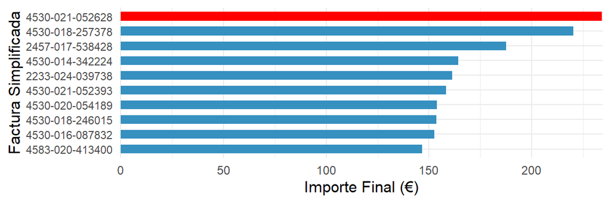

Figure 3.1: Top 10 tickets por importe final

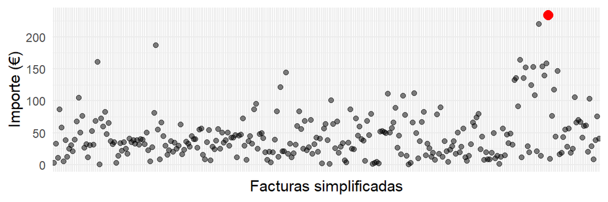

Figure 3.2: Importe de todos los tickets con el ticket máximo destacado

Como se puede observar, el ticket con mayor gasto es aquel al que le corresponde la factura simplificada: 4530-021-052628, cuyos productos se corresponden con los que se muestran en la tabla 3.1 .

Table 3.1: Productos del ticket máximo

| Factura_simplificada | Producto | Cantidad | Importe |
| --- | --- | --- | --- |
| 4530-021-052628 | JUDÍA PLANA 350 GR | 2 | 3.00 |
| 4530-021-052628 | ESP VERDE FINO | 3 | 5.97 |
| 4530-021-052628 | FRESÓN 1.3 KG | 1 | 3.10 |
| 4530-021-052628 | MIX DE SETAS INTENSO | 1 | 4.62 |
| 4530-021-052628 | PAN 51% INTEGRAL 5UN | 1 | 1.30 |
| 4530-021-052628 | PAN ESPELTA INTEGRAL | 1 | 1.40 |
| 4530-021-052628 | PAT. CLASSICAS | 1 | 1.75 |
| 4530-021-052628 | MINI EMP PISTO P6 | 1 | 1.70 |
| 4530-021-052628 | GALL DIGESTIVE | 1 | 1.75 |
| 4530-021-052628 | MINI SALADAS 24 UN | 1 | 2.50 |
| 4530-021-052628 | NARANJA 5 KG. | 1 | 5.95 |
| 4530-021-052628 | REBUENAS | 1 | 1.20 |
| 4530-021-052628 | CEBOLLA TIERNA | 1 | 1.29 |
| 4530-021-052628 | RABANITOS | 1 | 1.10 |
| 4530-021-052628 | ICEBERG | 1 | 0.99 |
| 4530-021-052628 | ACEITUNA PARTIDA | 1 | 3.90 |
| 4530-021-052628 | DEO AXE DARK TEMPT. | 1 | 3.15 |
| 4530-021-052628 | TARTA QUESO | 1 | 1.80 |
| 4530-021-052628 | QUESO AÑEJO FUERTE | 1 | 19.25 |
| 4530-021-052628 | CORTEZA DE CERDO | 1 | 1.00 |
| 4530-021-052628 | CONOS | 1 | 0.75 |
| 4530-021-052628 | CHAMPÚ H&S MENTOL | 1 | 4.25 |
| 4530-021-052628 | PIMENTON DULCE D.O | 1 | 1.75 |
| 4530-021-052628 | AZAFRAN HEBRA | 1 | 1.70 |
| 4530-021-052628 | CRUNCHY PICANTE | 1 | 1.00 |
| 4530-021-052628 | CARAMELO REGALIZ | 1 | 1.95 |
| 4530-021-052628 | LONGANIZA PASCUA | 1 | 2.43 |
| 4530-021-052628 | COSTILLA CHURRASCO | 1 | 5.38 |
| 4530-021-052628 | COSTILLA CHURRASCO | 1 | 4.44 |
| 4530-021-052628 | BACALAO AHUMADO | 1 | 3.20 |
| 4530-021-052628 | FIGATELL | 1 | 3.77 |
| 4530-021-052628 | COSTILLA CARNOSA | 1 | 5.11 |
| 4530-021-052628 | QUESO LONCHAS OVEJA | 1 | 2.72 |
| 4530-021-052628 | EMBUTIDO LONCHEADO | 1 | 4.90 |
| 4530-021-052628 | HAMBURGUESA DE LOMO | 1 | 3.70 |
| 4530-021-052628 | 1/2 CONEJO TROCEADO | 1 | 5.71 |
| 4530-021-052628 | 1/2 POLLO PART CERT | 1 | 6.91 |
| 4530-021-052628 | ALAS PARTIDAS CERT | 1 | 4.00 |
| 4530-021-052628 | QUESO LONCHAS OVEJA | 1 | 2.68 |
| 4530-021-052628 | VINO BAHIA DE DENIA | 1 | 4.90 |
| 4530-021-052628 | MARINA ALTA | 1 | 4.95 |
| 4530-021-052628 | TINTO BOBAL | 2 | 5.80 |
| 4530-021-052628 | SALCHICHON CEBO LONC | 1 | 1.89 |
| 4530-021-052628 | MAXI HAMBURGUESA | 1 | 0.90 |
| 4530-021-052628 | JAMÓN COCIDO 92% | 1 | 2.41 |
| 4530-021-052628 | JAMON CEBO IBERICO | 1 | 7.73 |
| 4530-021-052628 | JAMON CEBO IBERICO | 1 | 8.55 |
| 4530-021-052628 | JAMON CEBO IBERICO | 1 | 8.03 |
| 4530-021-052628 | GARROFON | 1 | 1.50 |
| 4530-021-052628 | FLTE BACALAO | 2 | 10.60 |
| 4530-021-052628 | BERBERECHO | 1 | 5.95 |
| 4530-021-052628 | CAÑAILLA | 1 | 2.90 |
| 4530-021-052628 | PESCADO - SEPIA LONJA | NA | 9.96 |
| 4530-021-052628 | PESCADO - BACALADILLA | NA | 4.34 |
| 4530-021-052628 | PESCADO - QUISQUILLA MEDIANA | NA | 7.76 |
| 4530-021-052628 | ALCACHOFA | 1 | 1.83 |
| 4530-021-052628 | HABAS | 1 | 8.30 |
| 4530-021-052628 | MANDARINA | 1 | 1.65 |
| 4530-021-052628 | TOMATE NEGRO | 1 | 1.18 |

## 3.2 ¿Cuál es el importe medio de los tickets por municipio? ¿Se observan diferencias significativas entre zonas?

Todos sabemos que no es lo mismo hacer la compra en el centro de una gran ciudad que en un pequeño pueblo. A veces cambia el ritmo, otras veces los precios, y en más de una ocasión, lo que llevamos en la cesta. Con esta pregunta, buscamos saber si hay municipios cuyos gatos sean mayores que otros: ¿dónde se registran tickets con un importe medio más alto? Veamos si hay municipios que destacan y si esas diferencias llaman la atención.

Table 3.2: Importe medio de tickets por municipio

| Municipio | Importe_Medio |
| --- | --- |
| ONTINYENT | 112.02 |
| ALCOI/ALCOY | 102.55 |
| REQUENA | 89.18 |
| MONCADA | 66.99 |
| SAGUNT/SAGUNTO | 66.30 |
| BENIFAIO | 64.34 |
| BUÑOL | 58.12 |
| VERA | 52.07 |
| SAN ANTONIO DE BENAGEBER | 49.74 |
| BENIJOFAR | 48.02 |
| MURO DE ALCOY | 45.02 |
| VALENCIA | 41.03 |
| BURJASSOT | 38.00 |
| ALGINET | 32.55 |
| ALBORAIA/ALBORAYA | 32.01 |
| GARRUCHA | 23.64 |
| GANDIA | 3.90 |
| SANTA EULÀRIA DES RIU | 3.08 |
| SANT JOSEP DE SA TALAIA | 0.77 |

Como se puede ver en la tabla 3.2 al analizar el importe medio de los tickets por municipio, se observan diferencias claras entre unas zonas y otras. Algunos municipios muestran un gasto promedio considerablemente más alto, lo que podría estar relacionado con distintos factores como el tamaño de las compras, la frecuencia con que se realizan, o incluso el perfil socioeconómico de la población. Estas variaciones indican que, efectivamente, no todos los municipios compran de la misma manera, y algunos tienden a realizar compras más costosas en promedio. Para una vista más clara, se puede observar tambien la figura 3.3.

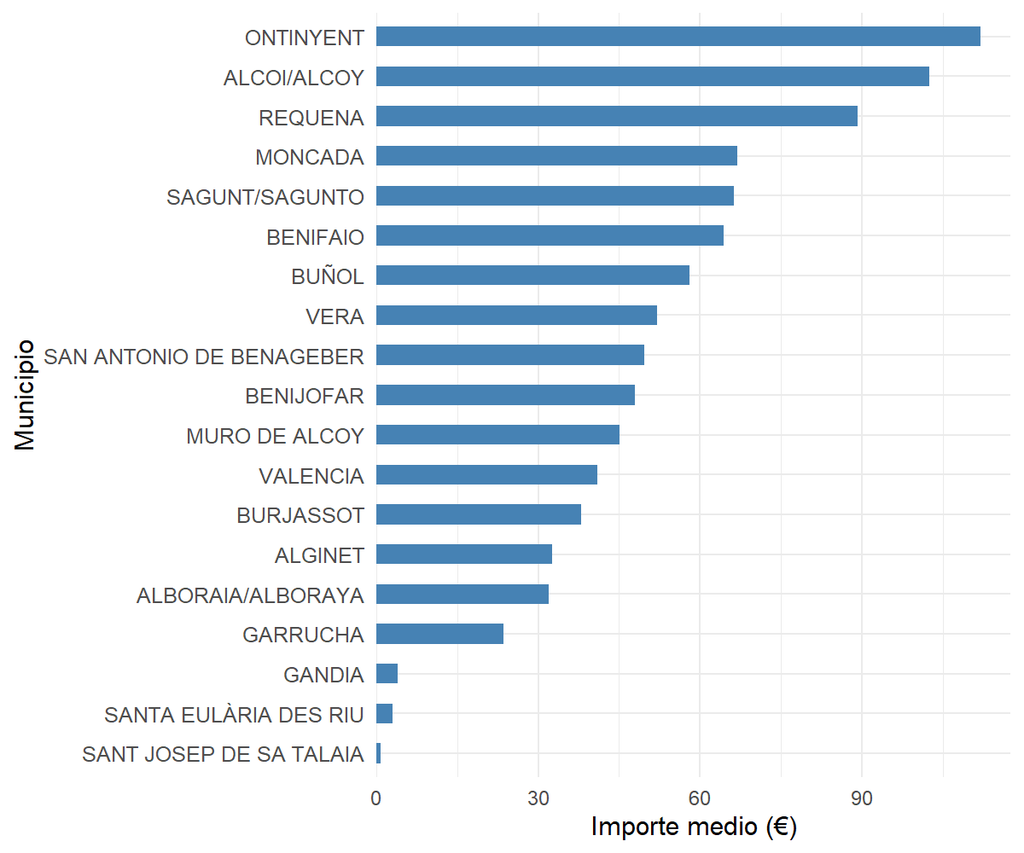

Figure 3.3: Importe Medio por municipio

## 3.3 ¿Cuál es la procedencia de los tickets? ¿Qué ciudad/pueblo tiene un mayor número de tickets?

Imaginemos que tenemos una gran caja registradora que guarda todos los tickets de Mercadona repartidos por pueblos y ciudades. Al abrirla, nos interesa saber de dónde viene la mayor parte del papel: ¿qué municipio aparece más veces en nuestro conjunto de datos? Es como contar votos en unas elecciones, pero aquí en vez de papeletas tenemos compras. Esta información nos puede dar una idea de dónde hay más actividad o más afluencia en las tiendas.

Table 3.3: Total de tickets por municipio

| Municipio | Total_Tickets |
| --- | --- |
| VALENCIA | 120 |
| ALBORAIA/ALBORAYA | 50 |
| BURJASSOT | 26 |
| MURO DE ALCOY | 24 |
| ALCOI/ALCOY | 22 |
| BUÑOL | 12 |
| BENIJOFAR | 8 |
| ALGINET | 5 |
| MONCADA | 5 |
| BENIFAIO | 4 |
| GARRUCHA | 4 |
| VERA | 3 |
| GANDIA | 1 |
| ONTINYENT | 1 |
| REQUENA | 1 |
| SAGUNT/SAGUNTO | 1 |
| SAN ANTONIO DE BENAGEBER | 1 |
| SANT JOSEP DE SA TALAIA | 1 |
| SANTA EULÀRIA DES RIU | 1 |

Como se ve en la tabla 3.3 , la mayoría de los tickets registrados provienen de un número reducido de municipios, siendo uno de ellos el que concentra el mayor volumen de compras. Se puede apreciar que Valencia destaca claramente por encima del resto, lo que sugiere una mayor frecuencia de compra o una mayor cantidad de transacciones en esa zona. Es posible que en ese lugar haya más tiendas, una mayor densidad de población, una clientela muy fiel a Mercadona o simplemente que nuestra muestra de datos esté sesgada a este municipio. Esto se puede visualizar más fácilmente en la gráfica 3.4

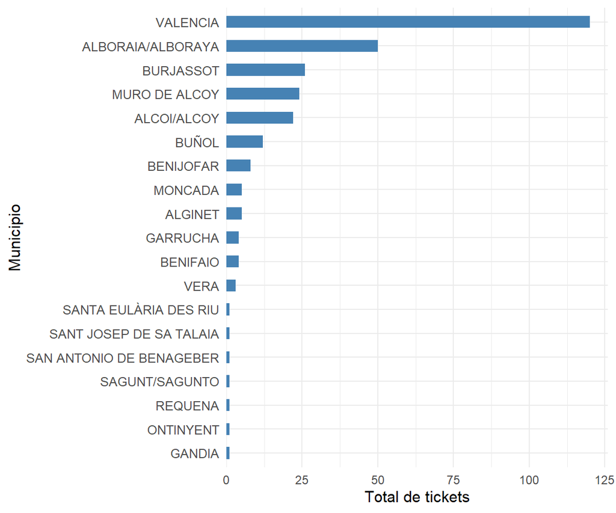

Figure 3.4: Número de tickets por municipio

## 3.4 ¿Qué porcentaje de las compras son de productos con peso (por kilo) frente a productos por unidad?

Cuando vamos al supermercado, es común ver etiquetas con productos que se venden por kilo (como la fruta, la carne o el pescado) y otros que se venden por unidad (como los packs de galletas o las botellas de agua). Pero, ¿alguna vez os habéis detenido a pensar cuál de estos tipos de productos es el más frecuente en las compras? ¿Somos más de llevar un kilo de manzanas o de escoger una caja de cereales? Vamos a analizar cómo se distribuyen las compras entre estos dos tipos de productos y qué porcentaje de nuestras cestas se llena con lo que pesamos frente a lo que contamos por unidad.

Table 3.4: Totales globales por tipo de producto

| tipo | n | Porcentaje |
| --- | --- | --- |
| Por peso | 399 | 8.29 |
| Por unidad | 4412 | 91.71 |

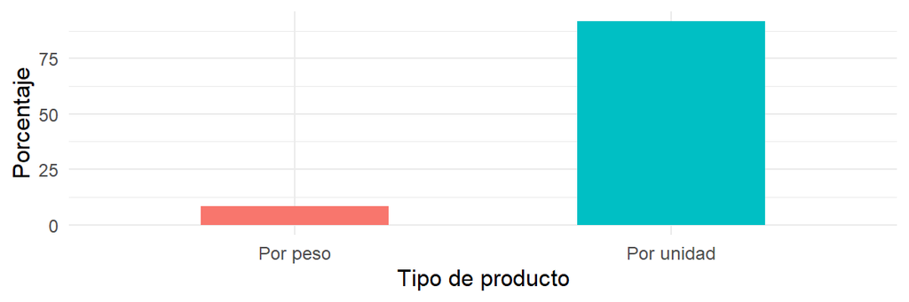

Figure 3.5: Porcentaje de productos por peso vs por unidad

Al observar la tabla 3.4 y el gráfico 3.5, se puede notar que una gran parte de las compras están compuestas por productos que se venden por unidad, como es el caso de los artículos de uso diario o de empaques predefinidos. Podemos llegar a la conclusión de que el porcentaje de productos con peso frente a los de unidad puede variar dependiendo del tipo de compra, pero en general, los productos por unidad parecen ser considerablememte más frecuentes en la mayoría de los tickets.

## 3.5 ¿Qué cantidad de productos es la más habitual en los tickets?

Cuando hacemos la compra, hay quienes llenan el carrito con solo unos pocos productos esenciales, mientras que otros pueden hacer una compra más extensas, cargando varias decenas de artículos. Pero, ¿cuál es la cantidad de productos más comúnmente registrada en un ticket promedio? ¿Nos estamos acercando más a la “compra rápida” o a la “compra de abastecimiento total”? Mediante el gráfico 3.6 podemos encontrar qué cantidad de productos aparece con mayor frecuencia y si estamos más cerca de hacer compras pequeñas o grandes.

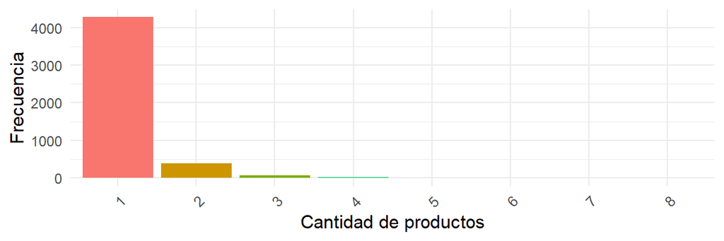

Figure 3.6: Frecuencia de cantidades de productos

Al analizar los datos, se observa que la cantidad de productos más habitual en los tickets tiende bastante a ser baja (literalmente de una unidad de producto). Es decir, la mayoría de los tickets reflejan compras mínimas de la mayoría de productos, lo que sugiere que la mayoría de los clientes tienden a hacer compras diarias o semanales, que nunca llegan a ser compras masivas, por lo menos no de un mismo producto.

## 3.6 Si consideramos la categoría de PESCADO. ¿Cuáles son los 5 productos más vendidos? ¿Cuántos kilos se han vendido de cada uno de estos productos?

El pescado es uno de esos productos que no puede faltar en muchas de nuestras compras. Desde el salmón hasta el bacalao, pasando por otras opciones más comunes como el atún, ¿pero cuáles son los pescados mas comprados de Mercadona? Para ello filtraremos por la categoría de “Pescado” y descubriremos cuáles son los 5 productos más vendidos. Y, ya que estamos, también veremos cuántos kilos de cada uno de estos productos han llegado hasta las cestas de los clientes.

Table 3.5: Top 5 productos sin cantidad (solo precio por kg)

| Producto | cant | kilos |
| --- | --- | --- |
| PESCADO - BACALADILLA | 5 | 5.782 |
| PESCADO - SEPIA FRESCA | 5 | 2.642 |
| PESCADO - SEPIA LONJA | 4 | 2.792 |
| PESCADO - LENGUADO FRESC EUROP | 3 | 1.248 |
| PESCADO - SEPIA SUCIA REFRIG | 3 | 2.402 |

## 3.7 Muestra mediante un diagrama el número de tickets recogidos cada día de la semana. Si tuvieses que cerrar un día entre semana, ¿qué día lo harías?

Cuando se trata de elegir el mejor día para hacer compras, no todos los días son iguales. Al igual que ocurre en los centros comerciales o en cualquier tienda, hay días de la semana en los que la afluencia de clientes es mucho mayor. Pero, ¿y si tuviéramos que elegir un día entre semana para cerrar? Analizando el número de tickets registrados por día, podemos descubrir qué día de la semana es en el que menos clientes se atreven a visitar Mercadona, para ello podemos agrupar los datos por día de la semana y graficarlos.

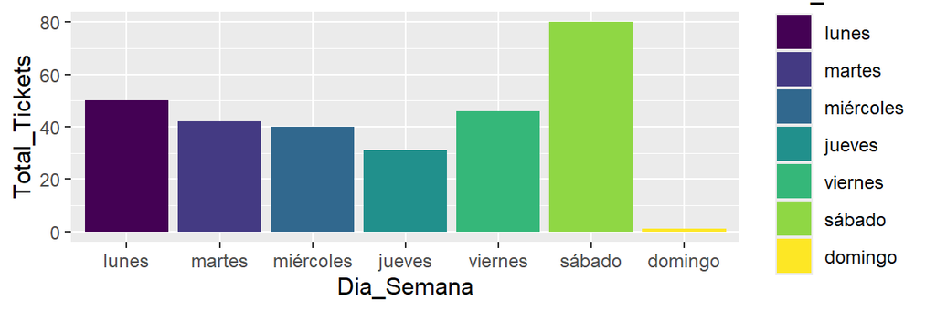

Figure 3.7: Número de tickets por día de la semana

Al analizar el gráfico 3.7 con número de tickets recogidos por cada día de la semana, se puede observar que el jueves es el día con la menor cantidad de compras y clientes. Este patrón resalta frente al resto de la semana, donde otros días, como el lunes o el sábado, muestran un mayor volumen de transacciones. Si se tuviera que elegir un día entre semana para cerrar, el jueves sería la opción más lógica, ya que es el día con menor actividad de compra.

## 3.8 ¿Qué categorías tienen mayor variabilidad en el precio a lo largo del tiempo?

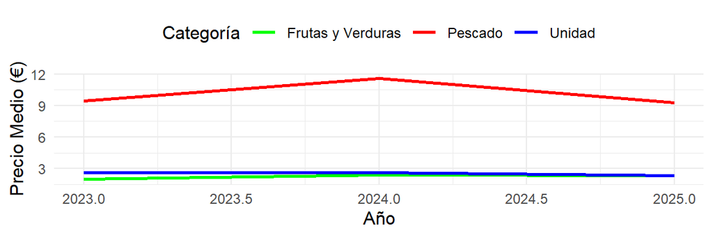

Figure 3.8: Comparación de precios medios por categoría de producto

## 3.9 ¿Qué relación hay entre el tiempo de estancia en el parking y el importe del ticket?

Ir al supermercado puede ser una experiencia rápida de cinco minutos o convertirse en toda una excursión de una hora. El tiempo que pasamos en el parking puede darnos pistas sobre qué tipo de compra hemos hecho: ¿solo un par de cosas o una gran compra mensual? Filtrando los tickets por tiempo de parking, vamos a investigar si existe una relación entre cuánto tiempo permanece una persona en el aparcamiento y cuánto dinero termina gastando.

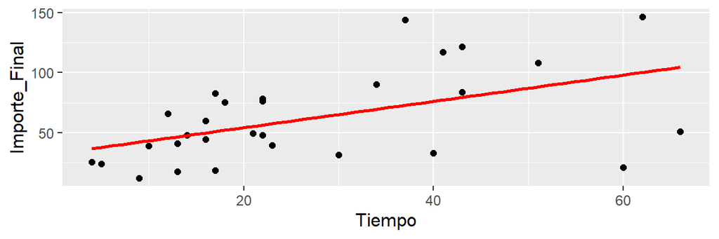

Figure 3.9: Relación entre estadía en el parking e importe del ticket

## 3.10 ¿Cuál es la distribución del gasto total por ticket? ¿Es simétrica o presenta valores extremos?

No todos gastamos lo mismo cuando vamos al supermercado: hay quienes van a por pan y leche, y quienes parece que están abasteciendo un refugio para seis meses. Esto se refleja en la distribución del gasto total por ticket. Al analizarla, podemos ver si la mayoría de las compras están en un rango similar o si hay algunas que se van por las nubes. Es como mirar una gráfica y preguntarse: ¿esto parece una campana equilibrada o más bien una montaña con una larga cuesta hacia un lado?

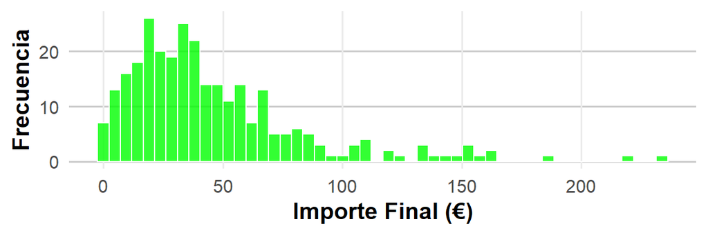

Figure 3.10: Distribución del importe de los tickets

La distribución del gasto total por ticket no es simétrica. La mayoría de los tickets se agrupan en torno a importes bajos o moderados, pero también existen compras con importes significativamente más altos que estiran la distribución hacia un extremo tal como se ve en la gráfica 3.10. Esto indica la presencia de valores extremos o compras atípicas que, aunque poco frecuentes, influyen en el comportamiento general del gasto.

## 3.11 ¿Qué 5 productos son más frecuentes por estación del año?

Las estaciones no solo cambian el clima, también cambian lo que metemos en el carrito. En verano, buscamos cosas frescas; en invierno guisos que reconforten; y en primavera… bueno, primavera es como un aperitivo del verano. Al mirar los datos por estaciones, podemos descubrir qué productos son los verdaderos protagonistas según la época del año. Para ello separamos los productos por fechas y estaciones y luego los agrupamos para contarlos, con lo cual podemos ver qué cinco productos brillan con luz propia en cada estación.

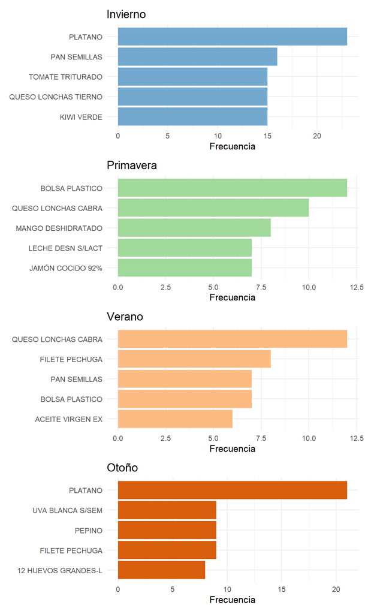

Figure 3.11: Productos mas frecuentes por estacion

## 3.12 ¿Cuál es la hora promedio de compra? ¿Los hábitos cambian en diferentes municipios?

Hay quienes prefieren madrugar para hacer la compra con calma y sin colas, y quienes se acercan al supermercado justo antes de que cierren, como si se tratara de una misión contrarreloj. Pero, en general, ¿a qué hora solemos hacer nuestras compras? Y lo más interesante: ¿esa rutina cambia dependiendo del municipio? Puede que en algunos lugares se compre justo después del desayuno, mientras que en otros lo habitual sea llenar el carrito a última hora de la tarde. Sacando el promedio de la hora de compra por municipio podemos averiguarlo.

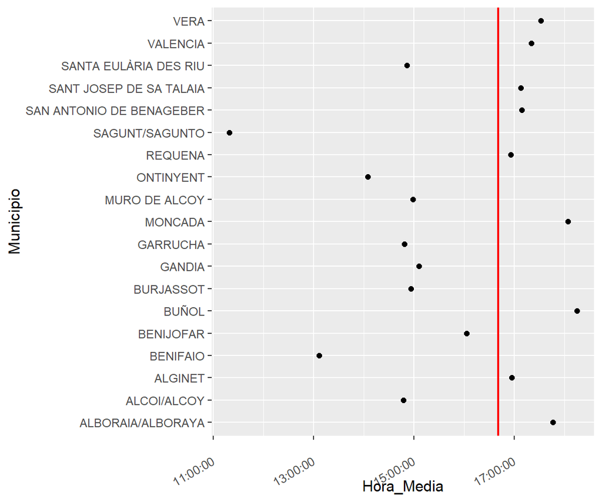

Figure 3.12: Hora media de compra por municipio

Como se ve en la gráfica 3.12, la hora promedio de compra varía entre municipios, lo que indica que los hábitos de consumo no son uniformes en todas las zonas. Aunque existe una franja horaria común donde se concentra la mayoría de las compras —normalmente en torno al mediodía o por la tarde—, algunos municipios muestran una tendencia más marcada hacia horarios tempranos o tardíos. Estas diferencias pueden deberse a factores como el estilo de vida local, el horario laboral predominante o incluso la ubicación de los supermercados en relación con las zonas residenciales.

## 3.13 ¿Cuál es el importe medio por kilogramo en productos de FRUTAS Y VERDURAS frente a PESCADO?

Estoy seguro de que todos sabemos que todos los kilos pesan igual.. al menos en el bolsillo. Comprar un kilo de manzanas no cuesta lo mismo que un kilo de salmón, y eso lo sabemos todos los que hemos tenido que elegir entre hacer una ensalada o preparar una cena más sofisticada. En esta pregunta queremos comparar el importe medio por kilogramo entre dos grandes grupos: las frutas y verduras, y el pescado. Es una forma sencilla de ver cuál de estas categorías representa una mayor inversión por parte del consumidor, la cual podemos resolver agrupando por estas categorias.

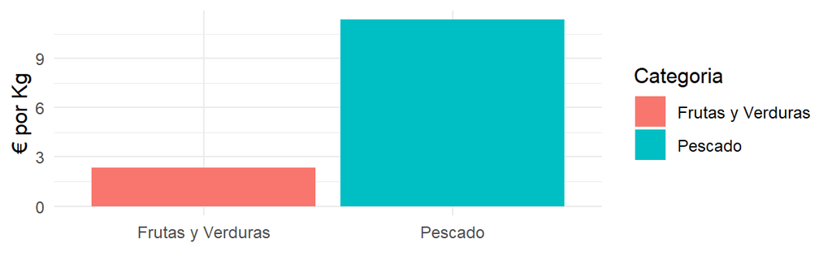

Figure 3.13: Precio medio por Kg

El análisis de la figura 3.13 deja en evidecia que el pescado es significativamente más caro por kilo en comparación con las frutas y verduras. Mientras que con frutas puedes llenar la bolsa por unos pocos euros, una buena merluza te deja la cartera tiritando. Esta diferencia es esperable por la naturaleza del producto, pero sirve para entender mejor cómo se distribuye el gasto en la compra.

## 3.14 ¿Qué municipios tienen tickets con importes promedio más altos en productos por unidad?

Cuando compramos productos por unidad, como paquetes de galletas, botellas de agua o artículos de uso cotidiano, el gasto tiende a ser más claro y predecible. Sin embargo, algunos municipios tienen tickets con importes promedio más altos en este tipo de productos. Esto podría reflejar un mayor consumo de marcas premium, una mayor variedad de productos o incluso un poder adquisitivo más elevado en algunas zonas. Al filtrar los productos que se venden por unidad podemos ver cuáles son esos municipios en los que los productos por unidad suponen un mayor desembolso.

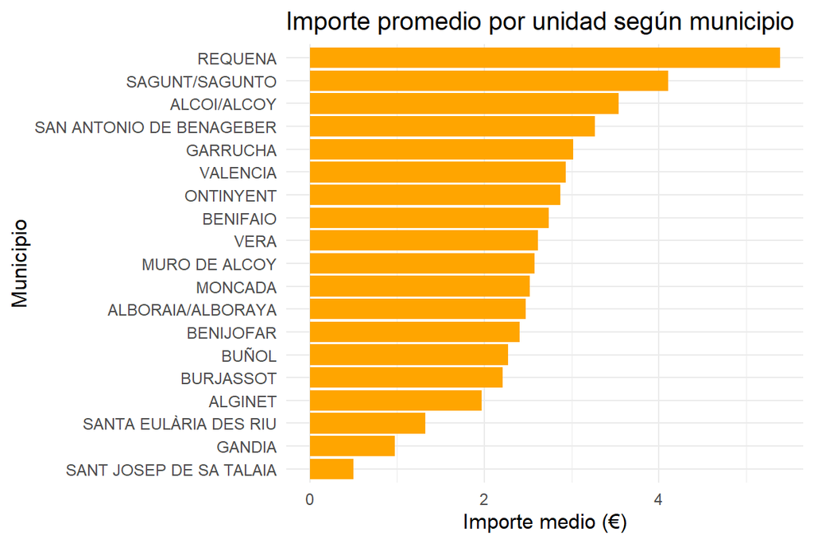

Como se puede ver en la figura 3.14, se observa que ciertos municipios tienen tickets con importes promedio más altos en productos por unidad, tales como Requena, Sagunto y Alcoy. Esto podría deberse a factores como la preferencia por marcas de mayor calidad, la adquisición de productos en cantidades más grandes o un mayor gasto por persona.

## 3.15 ¿Cuáles son los 5 productos, de los vendidos por unidades, con más ventas? ¿Cuántas unidades de cada uno se han vendido?

Hay ciertos productos que nunca faltan en las compras del día a día, como una botella de agua, un paquete de arroz o bananas. Pero, ¿cuáles son los más vendidos entre los productos que se venden por unidad? Vamos a analizar cuáles son los cinco productos más populares de esta categoría, y cuántas unidades de cada uno se han vendido. El analisis de estas cifras nos pueden dar una idea de los hábitos de compra más frecuentes.

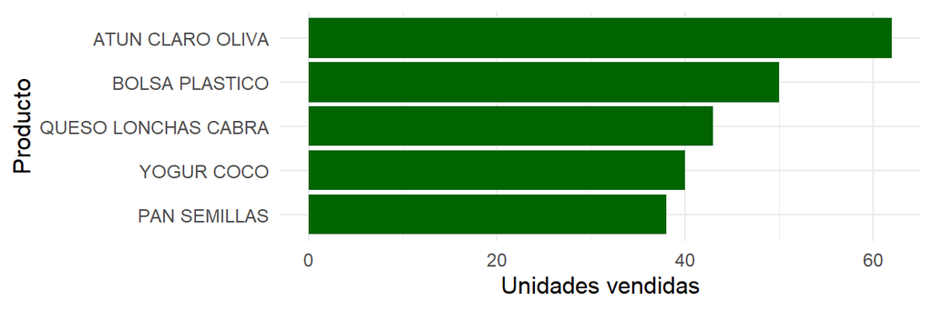

Figure 3.15: Top 5 productos vendidos por unidades

Los cinco productos más vendidos por unidad incluyen aquellos artículos que son esenciales en la mayoría de las compras, como pan, productos enlatados, pescado y ¿bolsas de plástico? Al analizar la figura 3.15, podemos ver que las unidades vendidas de estos productos son muy altas, lo que refleja su popularidad y el consumo frecuente entre los clientes. Algunos de estos productos, al ser de uso diario, tienen una rotación muy alta, convirtiéndolos en los más vendidos por unidad.

## 3.16 Si consideramos la categoría de FRUTAS Y VERDURAS. ¿Cuáles son los 5 productos más vendidos? ¿Cuántos kilos se han vendido de cada uno de estos productos?

Las frutas y verduras son esenciales en nuestra dieta, y no es raro que algunos de estos productos se vendan más que otros. Pero, ¿cuáles son los que más se repiten en las compras? ¿Y cuántos kilos de cada uno se han vendido a lo largo del tiempo? Al analizar esta categoría, podemos identificar qué productos frescos dominan las estanterías de Mercadona y cuánto se está consumiendo de cada uno. Además, podremos reutilizar el filtrado que se hizo en la pregunta 13 para ahorrarnos parte del trabajo.

Table 3.6: Top 5 productos más pesados de frutas y verduras

| Producto | Total_Kg |
| --- | --- |
| PLATANO | 56.31 |
| BANANA | 25.98 |
| SANDIA BAJA SEMILLAS | 22.84 |
| PEPINO | 19.62 |
| MELON PIEL SAPO | 16.18 |

## 3.17 ¿Cuál es el gasto medio por categoría de producto?

Cuando hacemos la compra, no solo nos fijamos en el total al final del ticket, sino también en cómo se distribuye nuestro gasto entre las diferentes categorías de productos. ¿Gastamos más en productos frescos, como frutas y verduras, o en productos envasados y no perecederos? Al analizar el gasto medio por categoría, podemos obtener una visión clara de en qué áreas estamos destinando la mayor parte de nuestro presupuesto. Este desglose nos ayuda a entender mejor cómo se distribuyen las compras en el día a día.

Table 3.7: Gasto medio por categoría

| categoria | Gasto_Medio |
| --- | --- |
| Pescado | 8.814348 |
| Productos varios | 2.753198 |
| Frutas/Verduras | 2.121671 |

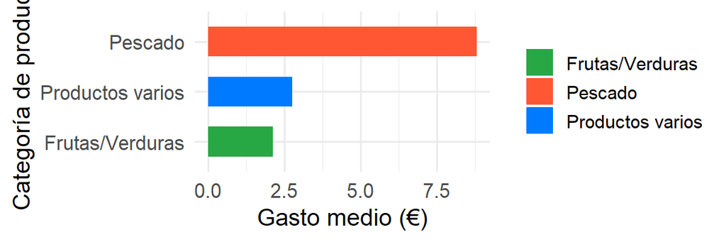

Figure 3.16: Gasto medio por categoría de producto

El gasto medio por categoría de producto (figura 3.16 y tabla 3.7) muestra que el pescado, tienden a concentrar una parte significativa del gasto total. Por otro lado, las categorías de productos no perecederos, como los productos enlatados o los artículos de limpieza, tienen un gasto medio más moderado, aunque constante. Con estos datos nos damos cuenta de que la diferencia de precio abismal que existe entre el pescado y el resto de productos.

## 3.18 Muestra mediante un gráfico de líneas cómo ha variado el precio por kilo de las bananas y los plátanos en los tickets disponibles, a lo largo del tiempo.

Las bananas y los plátanos son una de las frutas más comunes en nuestras cestas de la compra, pero ¿cómo ha variado su precio a lo largo del tiempo? A veces nos encontramos con que el precio de estas frutas sube o baja dependiendo de la temporada, las condiciones de oferta y demanda, o incluso de factores externos como la climatología. Vamos a analizar cómo ha cambiado el precio por kilo de estas frutas a lo largo del tiempo, y visualizaremos la evolución de sus precios mediante un gráfico de líneas.

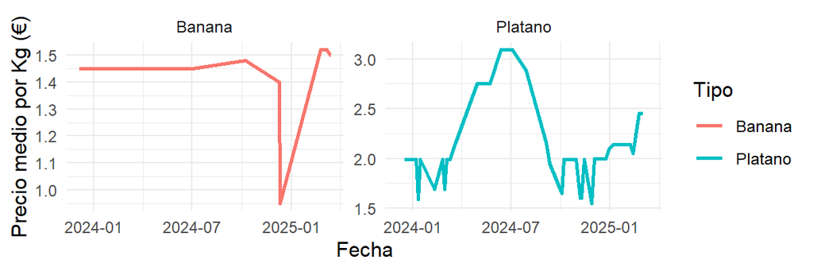

Figure 3.17: Evolución del precio por kilo de bananas y plátanos

# 4 Conclusiones

Tras analizar una serie de datos y desglosar las distintas preguntas sobre las compras realizadas en Mercadona, es hora de dar un paso atrás y reflexionar sobre los patrones que hemos encontrado. Desde el gasto promedio por categoría de producto, hasta las variaciones estacionales en la venta de productos, pasando por la relación entre el tiempo en el parking y el gasto total, todos estos análisis nos dan una visión más clara del comportamiento de los consumidores. Sin embargo, más allá de los números, las conclusiones nos invitan a pensar sobre cómo las tendencias de compra pueden reflejar cambios en nuestras costumbres, en nuestra economía y, por supuesto, en las estrategias comerciales de las empresas.

Al abordar todas las preguntas, podemos llegar a varias conclusiones clave sobre el comportamiento del consumidor en Mercadona:

- Variabilidad en el gasto y en los hábitos de compra: Hemos observado que el gasto promedio y las compras varían significativamente según la estación del año, el municipio o incluso el tipo de producto. Esto refleja no solo los cambios estacionales en la oferta y demanda, sino también las diferencias regionales en los hábitos de consumo. En este sentido, los hábitos de compra no son universales, sino que se adaptan a los gustos, preferencias y necesidades de cada grupo de consumidores.
- El impacto de factores externos en los precios: La variabilidad en los precios de productos como el pescado y las frutas y verduras a lo largo del tiempo subraya cómo los factores externos, como la estacionalidad o las condiciones del mercado, pueden influir en el gasto del consumidor. Los precios de algunos productos, como el pescado, son más susceptibles a estos cambios, lo que provoca una fluctuación en el precio por kilo, mientras que otros, como las frutas y verduras, mantienen un comportamiento más estable a lo largo del tiempo.

  Dicho esto agradecemos su atención y esperamos que haya sido útil esta investigacion.